# AE 01: UN Votes

Bora Jin

We want to look at the voting history of countries in the United Nations General Assembly using data from package `unvotes`.

```r
library(unvotes)
library(tidyverse)
theme_set(theme_bw())
library(lubridate)
library(DT)
library(scico)
```

## Data

We will work with three data sets: `un_roll_calls`, `un_roll_call_issues`, and `un_votes`. Each data set contains a variable called `rcid`, the roll call id, which can be used to join the data sets with one another.

- The `un_votes` data set provides information on the voting history of the United Nations General Assembly. It contains one row for each country/vote pair.

```r
un_votes
```

```
## # A tibble: 869,937 × 4
##     rcid country            country_code vote
##    <dbl> <chr>              <chr>        <fct>
##  1     3 United States      US           yes
##  2     3 Canada             CA           no
##  3     3 Cuba               CU           yes
##  4     3 Haiti              HT           yes
##  5     3 Dominican Republic DO           yes
##  6     3 Mexico             MX           yes
##  7     3 Guatemala          GT           yes
##  8     3 Honduras           HN           yes
##  9     3 El Salvador        SV           yes
## 10     3 Nicaragua          NI           yes
## # … with 869,927 more rows
```

- The `un_roll_calls` data set contains information on each roll call vote of the United Nations General Assembly.

```r
un_roll_calls
```

```
## # A tibble: 6,202 × 9
##     rcid session importantvote date       unres   amend  para short    descr
##    <int>   <dbl>         <int> <date>     <chr>   <int> <int> <chr>    <chr>
##  1     3       1             0 1946-01-01 R/1/66      1     0 AMENDME… "TO ADOP…
##  2     4       1             0 1946-01-02 R/1/79      0     0 SECURIT… "TO ADOP…
##  3     5       1             0 1946-01-04 R/1/98      0     0 VOTING … "TO ADOP…
##  4     6       1             0 1946-01-04 R/1/107     0     0 DECLARA… "TO ADOP…
##  5     7       1             0 1946-01-02 R/1/295     1     0 GENERAL… "TO ADOP…
##  6     8       1             0 1946-01-05 R/1/297     1     0 ECOSOC … "TO ADOP…
##  7     9       1             0 1946-02-05 R/1/329     0     0 POST-WA… "TO OPEN…
##  8    10       1             0 1946-02-05 R/1/361     1     1 U.N. ME… "TO ADOP…
##  9    11       1             0 1946-02-05 R/1/376     0     0 TRUSTEE… "TO ADOP…
## 10    12       1             0 1946-02-06 R/1/394     1     1 COUNCIL… "TO ADOP…
## # … with 6,192 more rows
```

- The `un_roll_call_issues` data set contains issue classifications of roll call votes of the United Nations General Assembly.

```r
un_roll_call_issues
```

```
## # A tibble: 5,745 × 3
##     rcid short_name issue
##    <int> <chr>      <fct>
##  1    77 me         Palestinian conflict
##  2  9001 me         Palestinian conflict
##  3  9002 me         Palestinian conflict
##  4  9003 me         Palestinian conflict
##  5  9004 me         Palestinian conflict
##  6  9005 me         Palestinian conflict
##  7  9006 me         Palestinian conflict
##  8   128 me         Palestinian conflict
##  9   129 me         Palestinian conflict
## 10   130 me         Palestinian conflict
## # … with 5,735 more rows
```

There are many votes that have no issue classification, and some are classified under more than one issue.

```r
un_roll_call_issues %>% filter(rcid == 3)
```

```
## # A tibble: 0 × 3
## # … with 3 variables: rcid <int>, short_name <chr>, issue <fct>
```

```r
un_roll_call_issues %>% filter(rcid == 6)
```

```
## # A tibble: 1 × 3
##    rcid short_name issue
##   <int> <chr>      <fct>
## 1     6 hr         Human rights
```

```r
un_roll_call_issues %>% filter(rcid == 11)
```

```
## # A tibble: 2 × 3
##    rcid short_name issue
##   <int> <chr>      <fct>
## 1    11 co         Colonialism
## 2    11 ec         Economic development
```

## Analysis

### Part 1

We begin by looking at how often each country voted “yes” on a resolution in each year. We’ll visualize the results focusing on permanent members of the UN Security Council.

```r
country_list <- c("United States", "Russia", "United Kingdom", "France", "China")
```

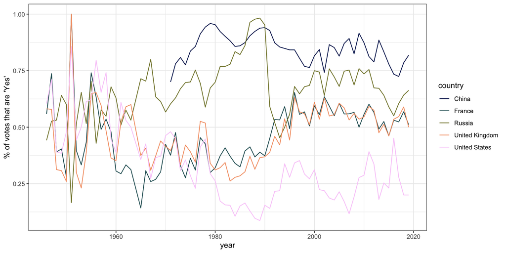

```r
un_votes %>%
  filter(country %in% country_list) %>%
  inner_join(un_roll_calls, by = "rcid") %>%
  group_by(year = year(date), country) %>%
  summarize(percent_yes = mean(vote == "yes")) %>%
  ggplot(mapping = aes(x = year, y = percent_yes, color = country)) +
  geom_line() +
  ylab("% of votes that are 'Yes'") +
  scale_color_scico_d()
```

### Part 2

Next, let’s see how the voting records have changed over the years on each of the issues.

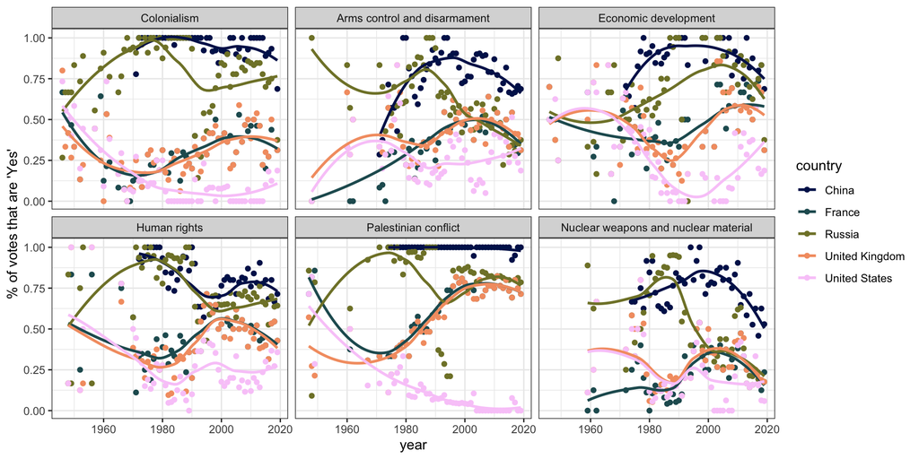

```r
un_votes %>%
  filter(country %in% country_list) %>%
  inner_join(un_roll_calls, by = "rcid") %>%
  inner_join(un_roll_call_issues, by = "rcid") %>%
  group_by(country, year = year(date), issue) %>%
  summarize(votes = n(),
            percent_yes = mean(vote == "yes")) %>%
  filter(votes > 5) %>%  # Only use records where there are more than 5 votes
  ggplot(mapping = aes(x = year, y = percent_yes, color = country)) +
  geom_point() +
  geom_smooth(method = "loess", se = FALSE) +
  ylab("% of votes that are 'Yes'") +
  facet_wrap(~ issue) +
  scale_color_scico_d()
```

### Discussion Questions

1. Consider the plot from Part 1. Describe how the voting behaviors of the five countries have changed over time.
2. Consider the plot from Part 2.
   - On which issues have the five countries (or majority of them) voted most similarly in recent years?
   - On which issues have they voted most differently in recent years?
   - Are there groups of countries with similar voting behaviors? If so, on what issues?
   - Has this changed over time?

## References

1. David Robinson (2017). unvotes: United Nations General Assembly Voting Data. R package version 0.2.0. https://CRAN.R-project.org/package=unvotes.
2. Erik Voeten “Data and Analyses of Voting in the UN General Assembly” Routledge Handbook of International Organization, edited by Bob Reinalda (published May 27, 2013).
3. This assignment was adapted from [UN Votes](https://github.com/rstudio-education/datascience-box/tree/master/appex/ae-01-un-votes) exercise and the examples presented in the [unvotes package vignette](https://cran.r-project.org/web/packages/unvotes/vignettes/unvotes.html).

## Appendix

Below is a list of countries in the data set:

```r
un_votes %>%
  arrange(country) %>%
  select(country) %>%
  distinct() %>%
  datatable()
```

|  | country |
| --- | --- |
| 1 | Afghanistan |
| 2 | Albania |
| 3 | Algeria |
| 4 | Andorra |
| 5 | Angola |
| 6 | Antigua &amp; Barbuda |
| 7 | Argentina |
| 8 | Armenia |
| 9 | Australia |
| 10 | Austria |

[output cut: 190 more lines]